(1.7 xG) **Inter** 4 - 3 **Fiorentina** (2.25 xG)

Serie A 2020-2021: Matchday 1 (Sep. 26, 2020)

Minute

Team

Player

Result

Shot Map

Cumulative xG

Situation

Shot Type

Assist Player

Assist Action

2

Fiorentina

Christian Kouamé

GOAL ⚽

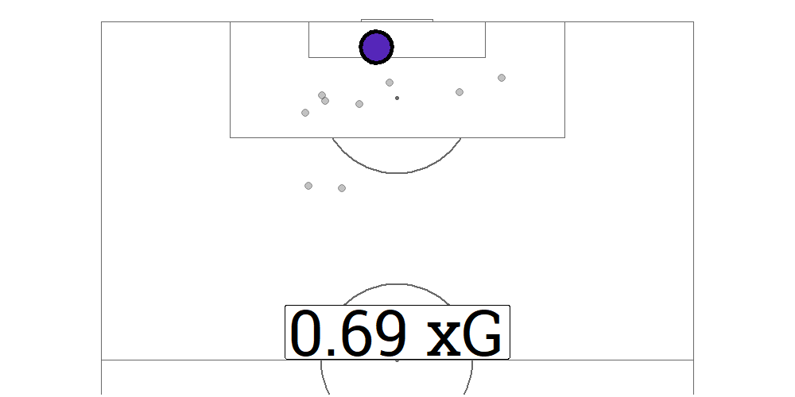

0.69

Open Play

Right Foot

Giacomo Bonaventura

Pass

8

Fiorentina

Cristiano Biraghi

Missed Shot

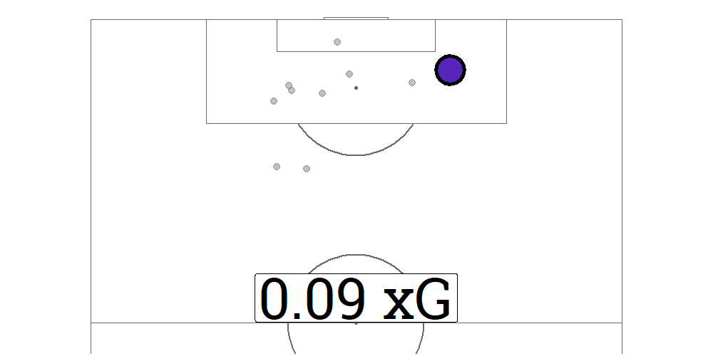

0.78

Open Play

Left Foot

Franck Ribéry

Pass

10

Inter

Ivan Perisic

Missed Shot

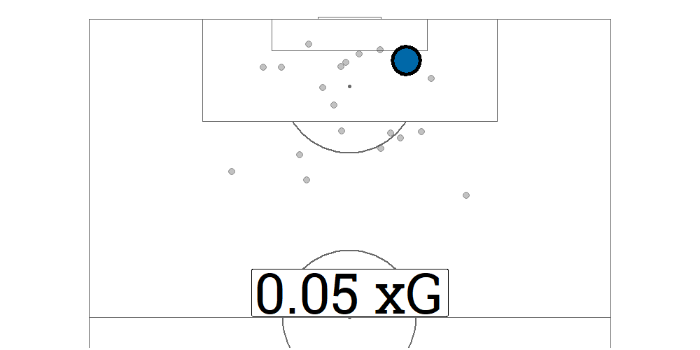

0.05

Open Play

Head

Ashley Young

Cross

15

Inter

Aleksandar Kolarov

Blocked Shot

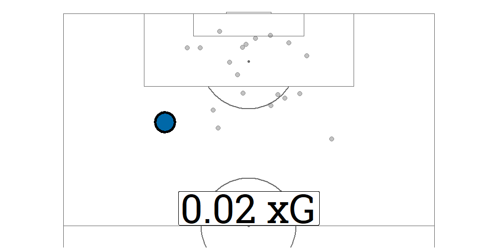

0.06

From Corner

Left Foot

Ashley Young

Pass

16

Fiorentina

Christian Kouamé

Saved Shot

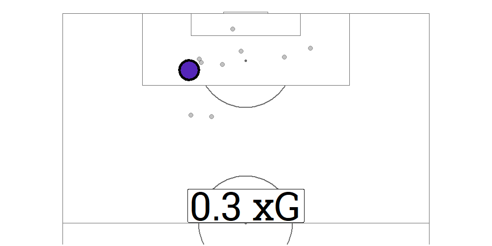

1.09

Open Play

Right Foot

Franck Ribéry

Chipped

20

Inter

Romelu Lukaku

Missed Shot

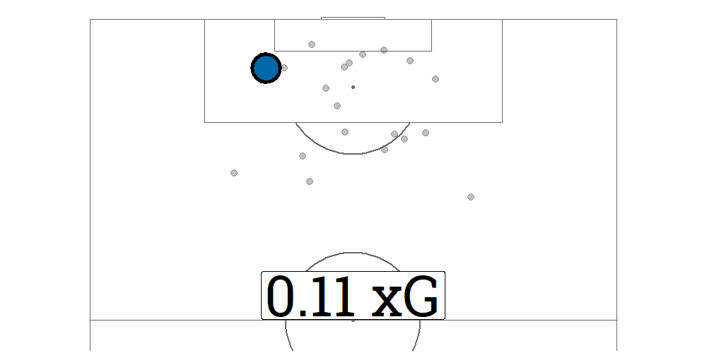

0.17

Open Play

Right Foot

Christian Eriksen

Chipped

23

Fiorentina

Nikola Milenkovic

Missed Shot

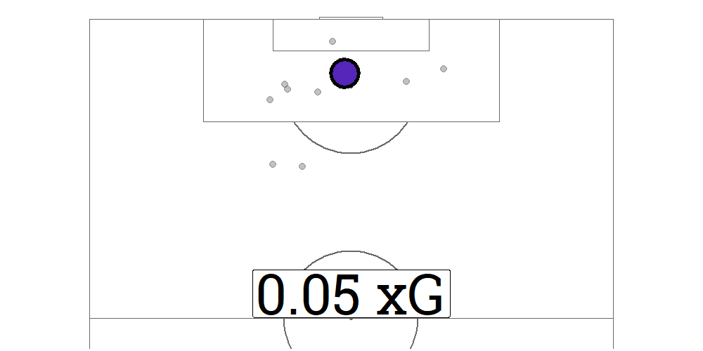

1.14

Set Piece

Head

Christian Kouamé

Aerial

33

Inter

Romelu Lukaku

Blocked Shot

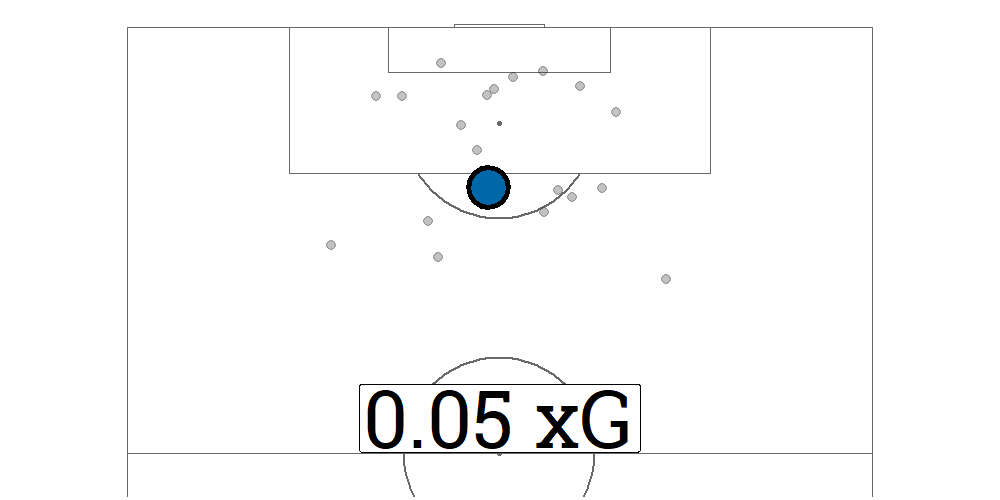

0.22

Open Play

Left Foot

Nicolò Barella

Pass

34

Inter

Aleksandar Kolarov

Missed Shot

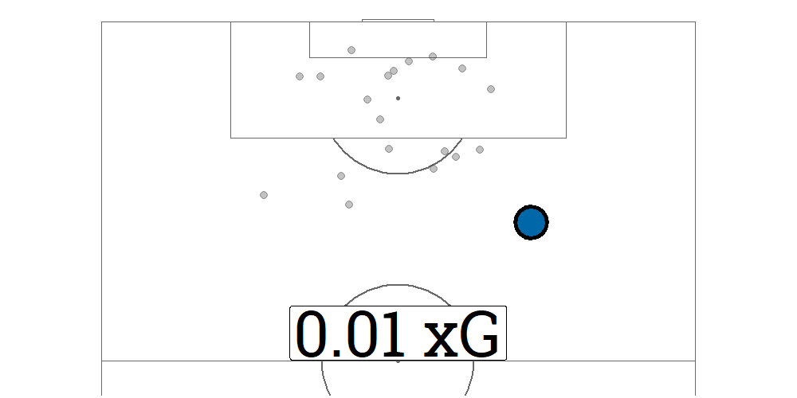

0.23

Open Play

Left Foot

Marcelo Brozovic

Pass

40

Fiorentina

Christian Kouamé

Missed Shot

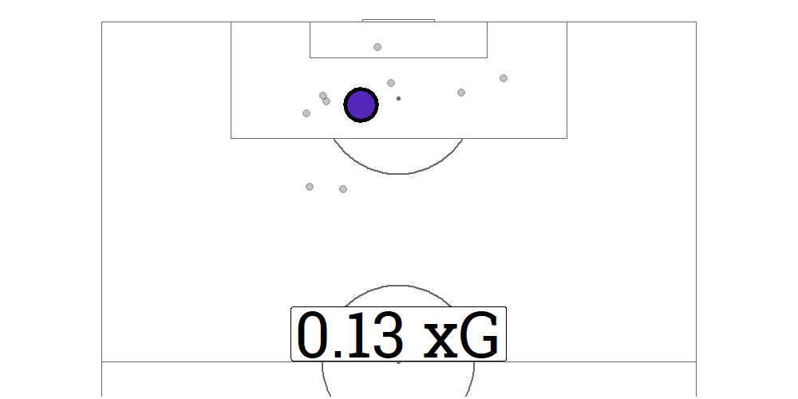

1.27

Open Play

Right Foot

Take On

43

Inter

Ivan Perisic

Missed Shot

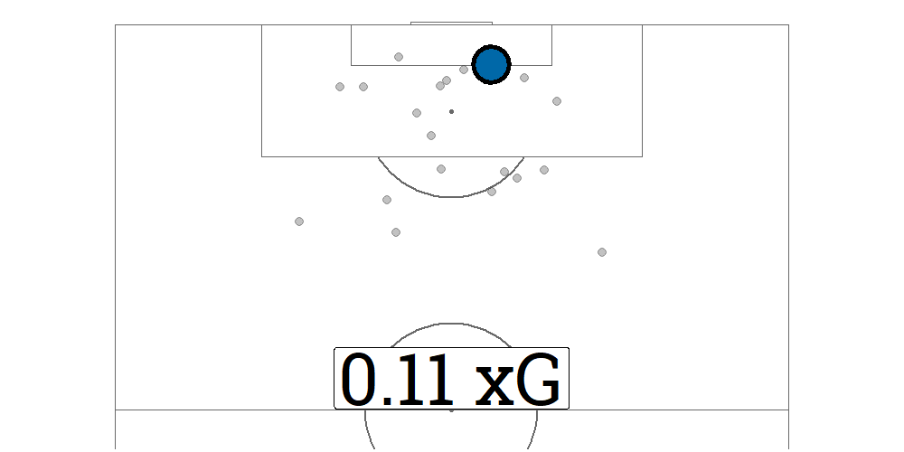

0.34

Open Play

Left Foot

Ashley Young

Cross

46

Inter

Lautaro Martínez

GOAL ⚽

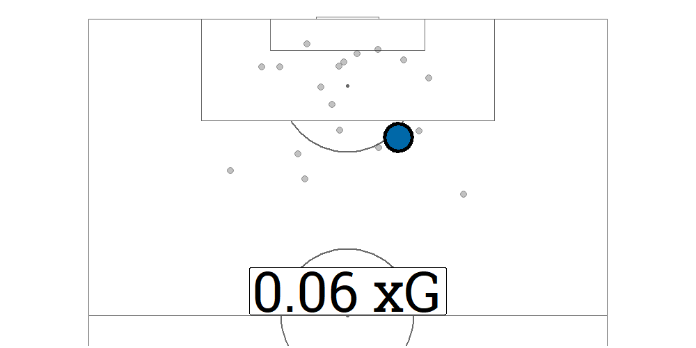

0.40

Open Play

Right Foot

Nicolò Barella

Pass

48

Inter

Romelu Lukaku

Missed Shot

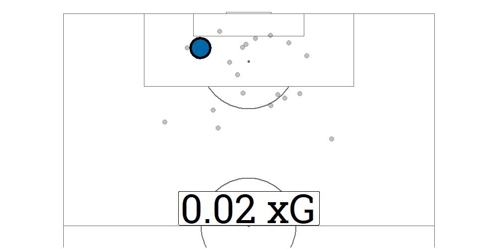

0.43

Open Play

Head

Nicolò Barella

Cross

51

Inter

Lautaro Martínez

Blocked Shot

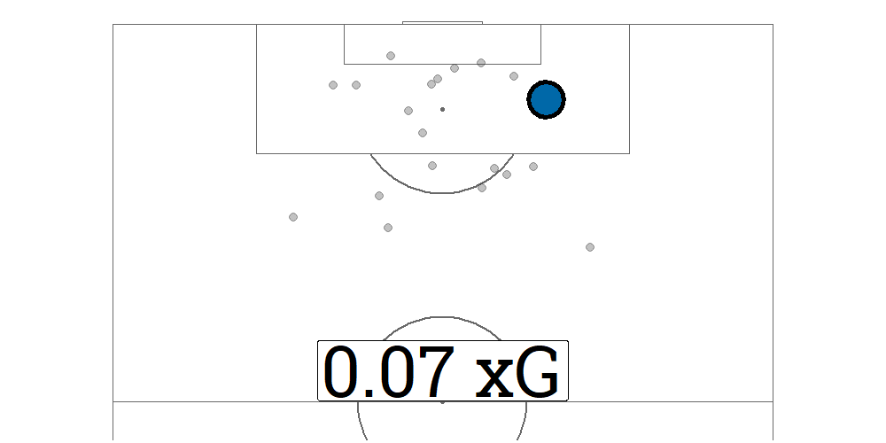

0.49

Open Play

Right Foot

Christian Eriksen

Chipped

51

Inter

Federico Ceccherini

OWN GOAL ⚽

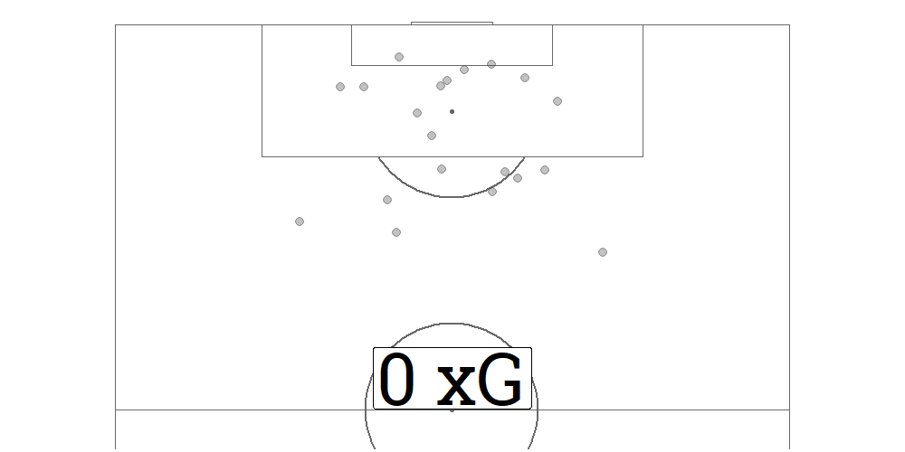

NA

Open Play

Right Foot

Save

55

Fiorentina

Giacomo Bonaventura

Blocked Shot

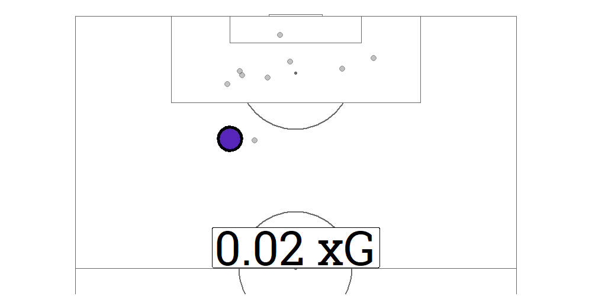

1.28

Open Play

Left Foot

Federico Chiesa

Pass

56

Fiorentina

Gaetano Castrovilli

GOAL ⚽

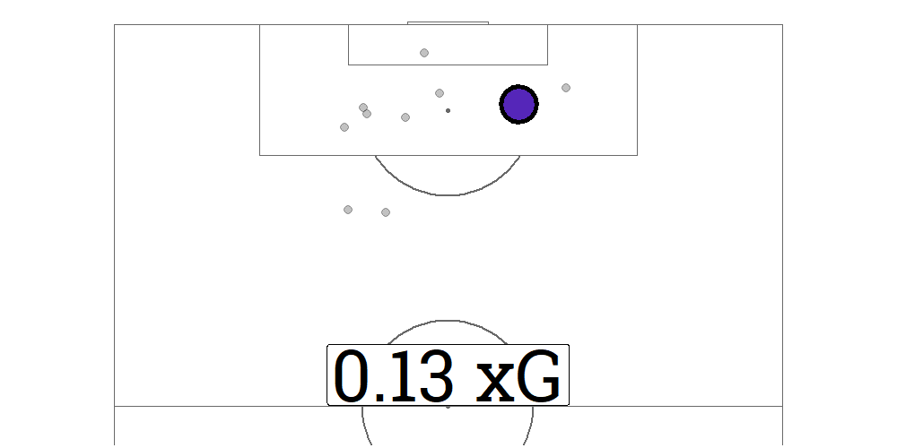

1.42

Open Play

Left Foot

Franck Ribéry

Pass

60

Inter

Ivan Perisic

Missed Shot

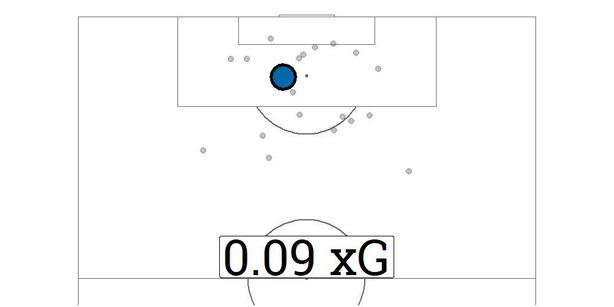

0.59

Open Play

Right Foot

Marcelo Brozovic

Chipped

61

Inter

Marcelo Brozovic

Blocked Shot

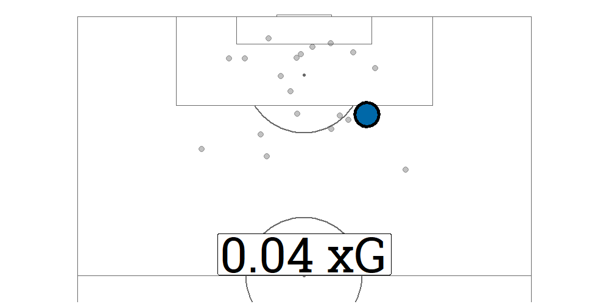

0.62

Open Play

Right Foot

Lautaro Martínez

Take On

62

Fiorentina

Federico Chiesa

GOAL ⚽

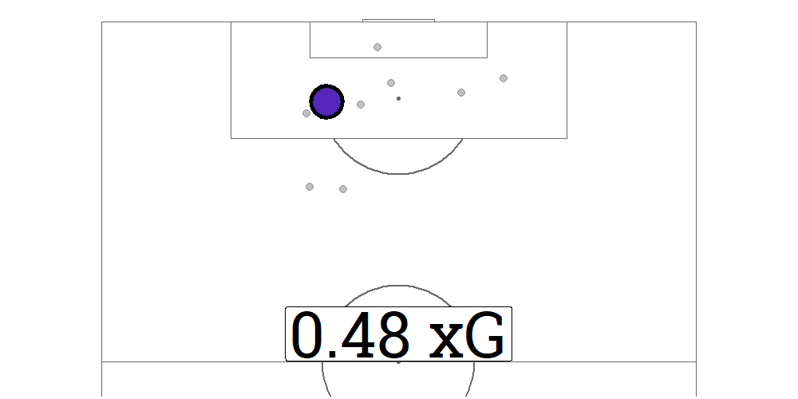

1.90

Open Play

Right Foot

Franck Ribéry

Through ball

67

Inter

Romelu Lukaku

Missed Shot

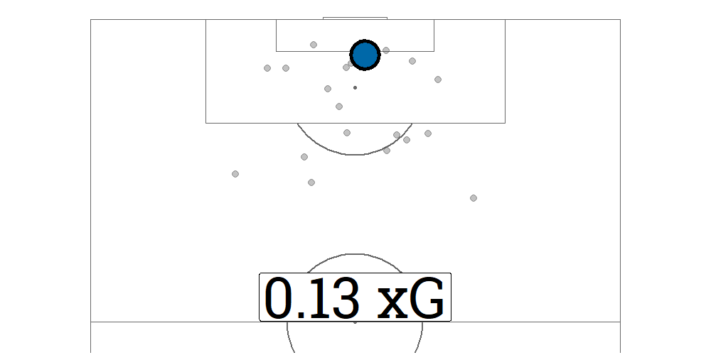

0.76

Open Play

Left Foot

Ivan Perisic

Pass

68

Inter

Lautaro Martínez

Saved Shot

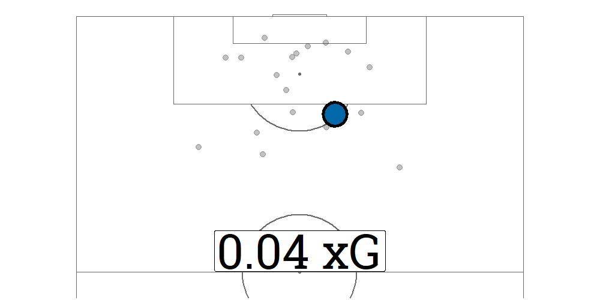

0.80

Open Play

Right Foot

69

Inter

Stefano Sensi

Blocked Shot

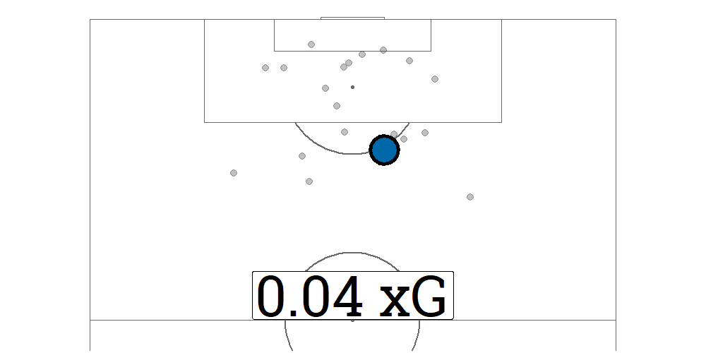

0.83

Open Play

Right Foot

Marcelo Brozovic

Pass

71

Fiorentina

Dusan Vlahovic

Missed Shot

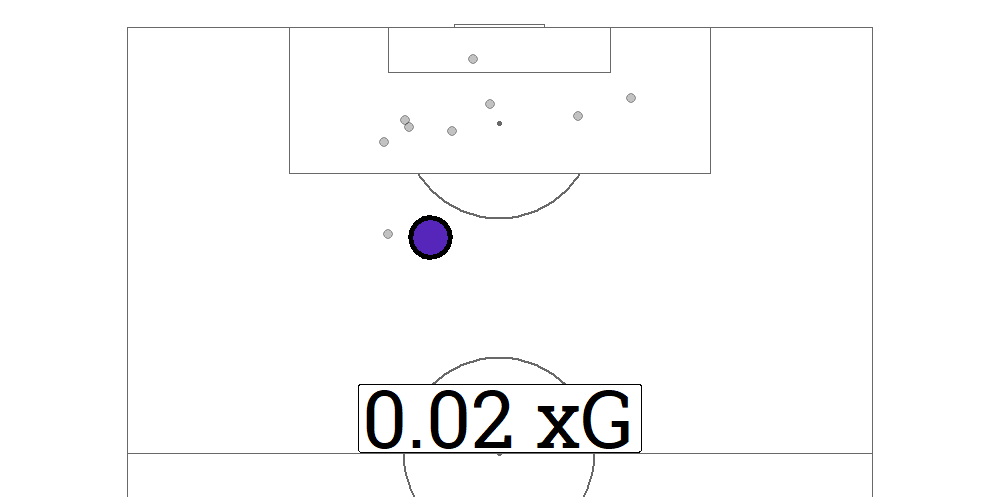

1.92

Open Play

Left Foot

Pol Lirola

Pass

71

Inter

Romelu Lukaku

Saved Shot

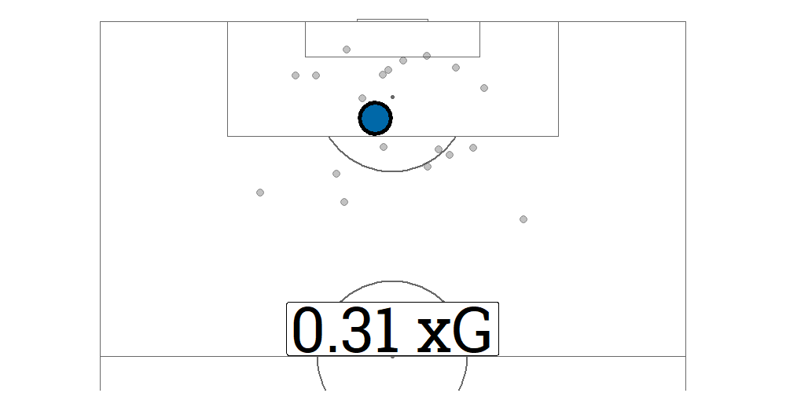

1.14

Open Play

Right Foot

Aleksandar Kolarov

Pass

72

Inter

Nicolò Barella

Saved Shot

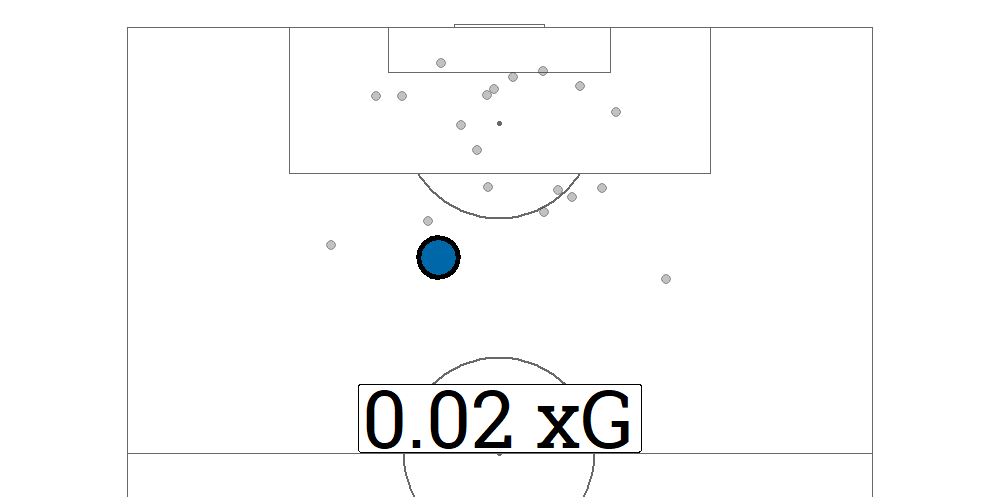

1.16

Open Play

Right Foot

Alessandro Bastoni

Pass

76

Inter

Stefano Sensi

Saved Shot

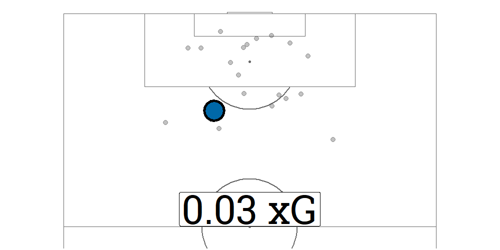

1.19

Open Play

Right Foot

Arturo Vidal

Pass

80

Fiorentina

Dusan Vlahovic

Missed Shot

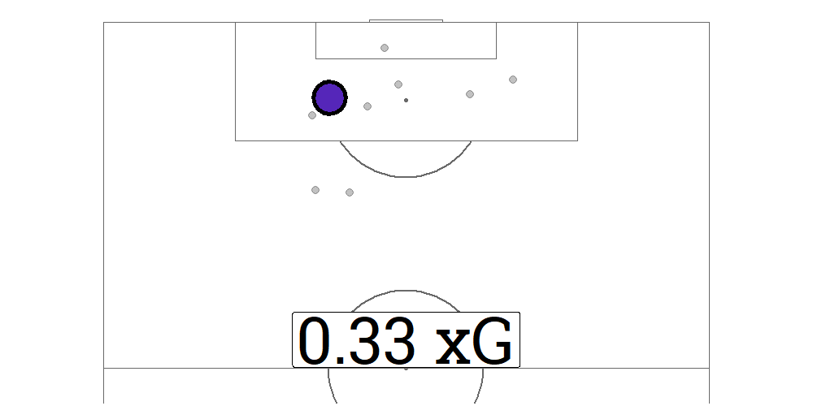

2.25

Open Play

Right Foot

Franck Ribéry

Pass

81

Inter

Arturo Vidal

Blocked Shot

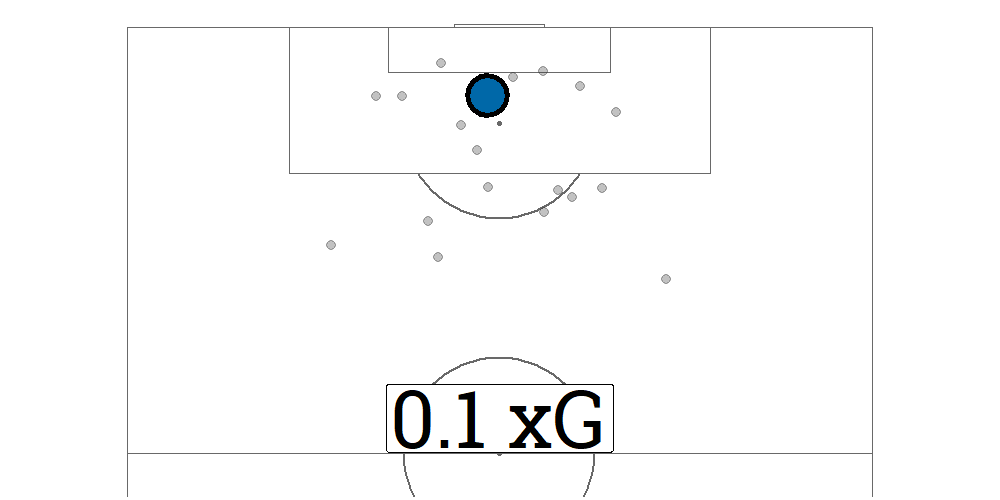

1.29

Open Play

Head

Alexis Sánchez

Cross

86

Inter

Romelu Lukaku

GOAL ⚽

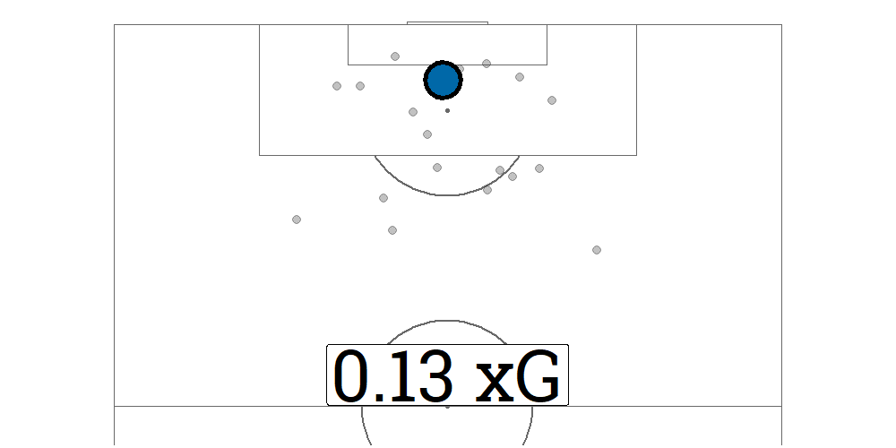

1.42

Open Play

Right Foot

Achraf Hakimi

Pass

88

Inter

GOAL ⚽

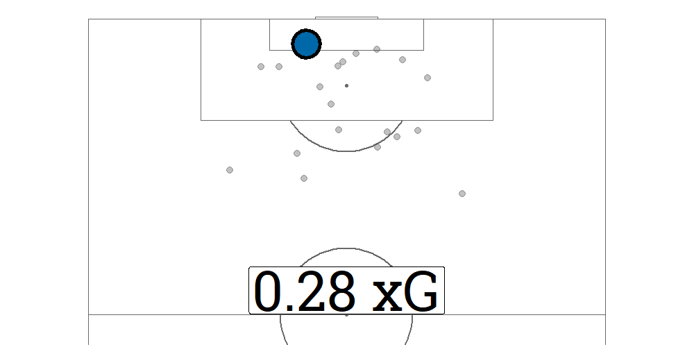

1.70

From Corner

Head

Alexis Sánchez

Aerial

**Table**: Ryo Nakagawara (**Twitter**: @R_by_Ryo) | **Data**: understat